# Homework #1

March 15, 2017

# Домашняя работа №1

В этой домашней работе от вас потребуется модифицировать Rmd файл с занятия, чтобы в нем появились фишки, описанные ниже.

## Removing outlier

Прежде всего, из первого PCA-графика и из heatmaps было видно, что один из наших образцов является аутлаером. Его нужно убрать из всего анализа. Лучше всего это сделать в начале кода, сразу после чтения файла counts.

## Volcano plot: add some colors

В этой части задания от вас потребуется покрасить дифференциально экспрессированные гены (гены с p.adj < 0.01) в красный, а также провести линию с p.adj = 0.01. Кроме покраски некоторых генов, хочется сравнить два volcano plot: первый (такой же как на паре, T regulatory cells vs conventional CD4+ T cells) и второй (нужно сделать самим: breast tumor vs Normal breast tissue). В итоге от вас хочется картинку в духе:

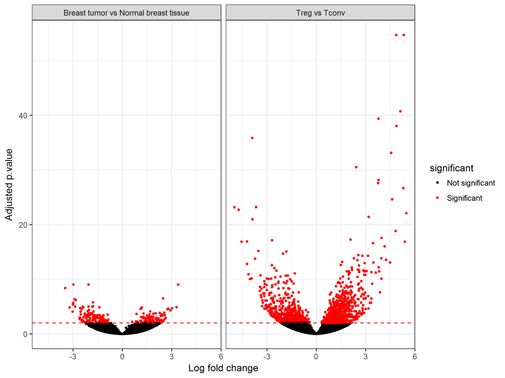

из подсказок ggplot2::facet_grid, geom_hline и scale_color_manual

## Визуализация пасвея

Помните GO-term, который был в самом верху нашего анализа? Да-да, “GO:0007159: leukocyte cell-cell adhesion”. Вот хочется взять **все** гены из него, и положить на хитмапу. Гены из пасвея можно достать следующим образом:

```r
library(org.Hs.eg.db)
library(dplyr)

kkeys <- keys(org.Hs.eg.db, keytype="ENSEMBL")
goAnno <- AnnotationDbi::select(org.Hs.eg.db, keys=kkeys,
                                keytype="ENSEMBL", columns=c("GOALL", "ONTOLOGYALL", "SYMBOL"))
goAnno <- tbl_df(goAnno)
goAnno <- filter(goAnno, GOALL=="GO:0007159")
# or you can pick ENTREZ, or SYMBOL, or whatever you want
genesToVisualise <- goAnno$ENSEMBL
```

От вас же требуется отсортировать эти гены в порядке их статистики (колонка *stat*) дифф. экспрессии в табличке *res*, и затем построить тепловую карту экспрессии этих генов в этом порядке. Ожидается увидеть что-то в духе:

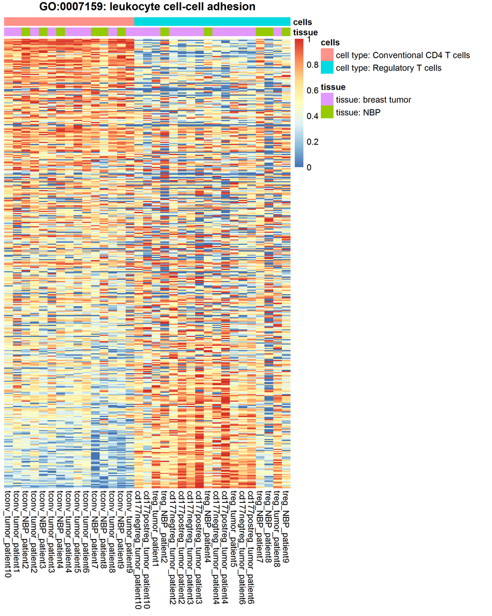

## Ven diagrams, genes intersections

После того, как мы сделали сравнения Treg vs Tconv и Tumor breast vs Normal breast, мы можем оценить есть ли у этих сравнения общие дифференциально экспрессированные гены. Для этого мы возьмем из обоих сравнений гены с $p.adj < 0.01$ и построим диаграмму Венна! Для этого вам понадобится пакет *VennDiagram* и функция *draw.pairwise.venn*, которая рисует диаграммы Венна для двух множеств

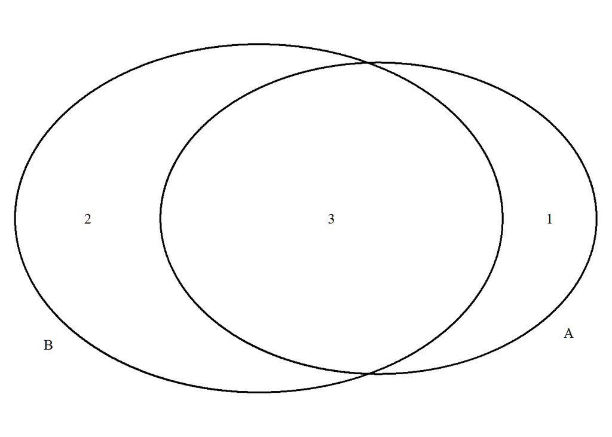

```
## (polygon[GRID.polygon.1], polygon[GRID.polygon.2], polygon[GRID.polygon.3], polygon[GRID.polygon.4], text[GRID.text.5], text[GRID.text.6], text[GRID.text.7], text[GRID.text.8], text[GRID.text.9])
```

```r
library(VennDiagram)

setA <- c("A", "B", "C", "D")
setB <- c("B", "C", "D", "E", "F")
commonLetters <- intersect(setA, setB)

draw.pairwise.venn(length(setA), length(setB), length(commonLetters),
                   category = c("A", "B"))
```

От вас же требуется проделать то же самое для дифф.экспрессированых генов в двух сравнениях. Должно получится что-то в духе:

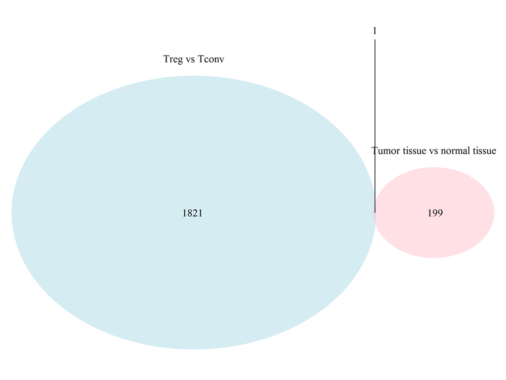

## Вишенка на торте

Как я и сказал, я бы хотел смотреть ваш код на Github, поэтому вам всем придется там зарегистрироваться, и научиться с ним работать. Github – это по сути облачное хранилище для кода и одновременно система контроля версий. Про установку git, и создание аккаунта на github, можно почитать на вики, которую в прошлом году писали студенты. [Ссылка](https://goo.gl/SdrJSN).

Я хочу, чтобы вы создали репозиторий с названием в духе “bioinf in R”, создали в репозитории папку homework1, и залили туда исправленный Rmd-файл и результат исполнения этого файла (pdf или html).

## Deadline

Время на исполнение домашней работы – две недели, таким образом дедлайн 29 марта, 23:59:59. После этого времени домашние работы не принимаются. (Ну точнее принимаются, и возможно даже проверяются, но баллы не получаются, ну вы поняли)